# Project: EdTech Lead Conversion Prediction

### Visualization of Decision Tree

**Important Information**

- **Depth**: Hyperparameter tuning restricted the maximum depth to a specific range, preventing the decision tree from growing until nodes are homogeneous.
- **Color** Intensity: Darker colors indicate purer nodes, while lighter colors indicate mixed nodes.
- **Color**: The specific colors correspond to different classes (blue: converted leads y[1], orange: non-converted leads y[0]).
- **Node Information**: Each node contains information about the split criterion, entropy (or impurity), number of samples, class distribution, and the majority class.

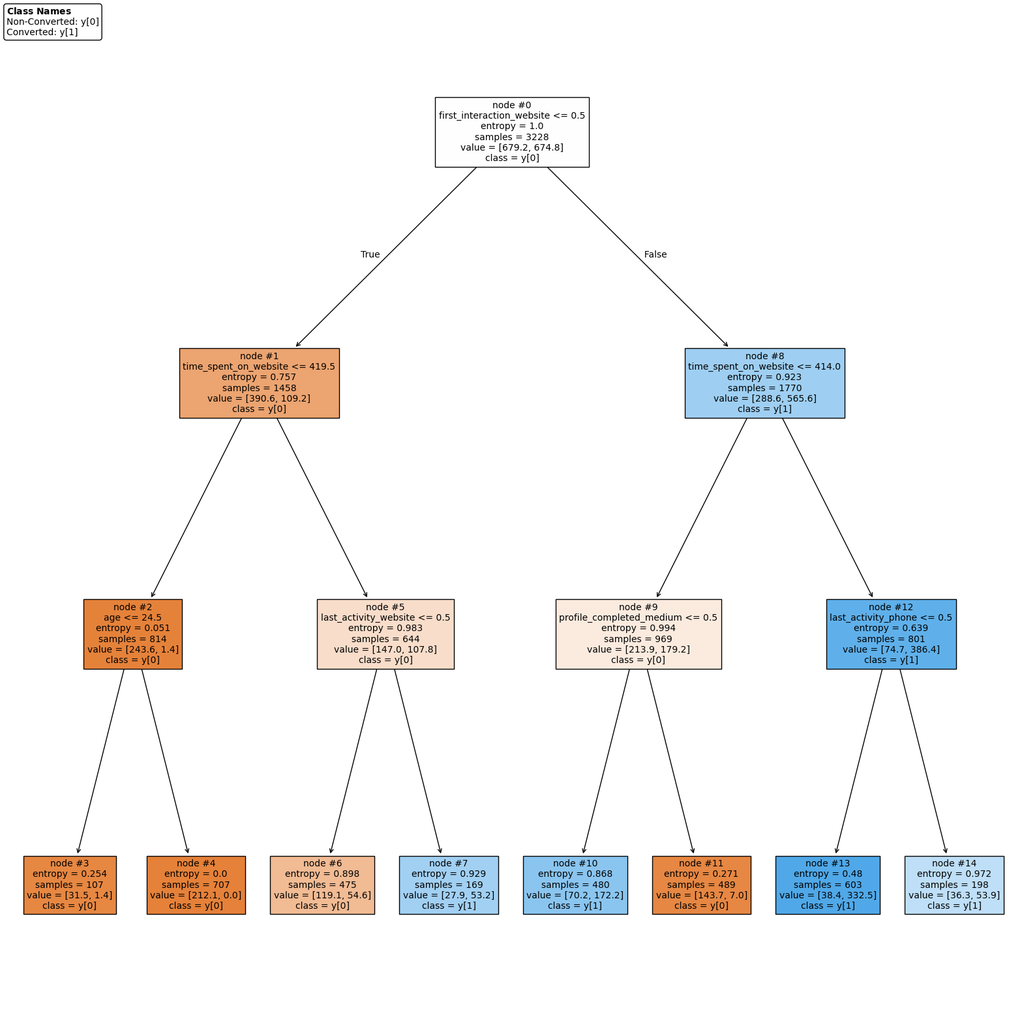

```python
# Visualizing of the decision tree and the observed decision rules
features = X_train.columns.tolist()

plt.figure(figsize=(20, 20))
tree.plot_tree(
    model_dt_tuned,
    feature_names=features,
    filled=True,
    fontsize=10,
    node_ids=True,
    class_names=True,
)

# Add annotation to the figure
plt.annotate(
    r"$\mathbf{Class\ Names}$" + "\n" + "Non-Converted: y[0]\nConverted: y[1]",
    xy=(0, 1),
    xycoords="axes fraction",
    fontsize=10,
    ha="left",
    va="top",
    bbox=dict(boxstyle="round,pad=0.3", edgecolor="black", facecolor="white"),
)
plt.show()
```

**Observations**:

- **Hierarchical Structure**: The decision tree’s structure illustrates feature importance based on decision rules formed by a greedy algorithm.
- **Tuned Model Depth**: The tuned model is limited to three levels, with key features such as the initial interaction, engagement time, and other variables driving lead conversion predictions.
- **Paths to Classification**: Each path, representing a sequence of nodes from root to leaf, defines a classification rule tailored to a specific subset of data records.
- **Leaf Nodes**: Each leaf node signifies the final classification label, determined by the majority rule. Lower entropy values indicate greater homogeneity in the outcomes.

### Feature Importance

Feature importance is evaluated based on each feature’s contribution to the splits in the decision tree, highlighting the critical predictors driving model decisions.

```python
# Get the feature names from the original DataFrame
features = X_train.columns

# Extract the feature importances
importances = model_dt_tuned.feature_importances_

# Create a DataFrame to display the feature importance
importance_df = pd.DataFrame(
    importances, index=features, columns=["relative_importance"]
).sort_values(by="relative_importance", ascending=False)

print("Feature Importances | Decision Tree")
print("-" * 52)
print(importance_df)
print("-" * 52)
```

```
Feature Importances | Decision Tree
----------------------------------------------------
                               relative_importance
time_spent_on_website                     0.365546
first_interaction_website                 0.313484
profile_completed_medium                  0.233702
last_activity_phone                       0.048402
last_activity_website                     0.032013
age                                       0.006853
website_visits                            0.000000
page_views_per_visit                      0.000000
current_occupation_student                0.000000
current_occupation_unemployed             0.000000
profile_completed_low                     0.000000
print_media_type1_yes                     0.000000
print_media_type2_yes                     0.000000
digital_media_yes                         0.000000
educational_channels_yes                  0.000000
referral_yes                              0.000000
----------------------------------------------------
```

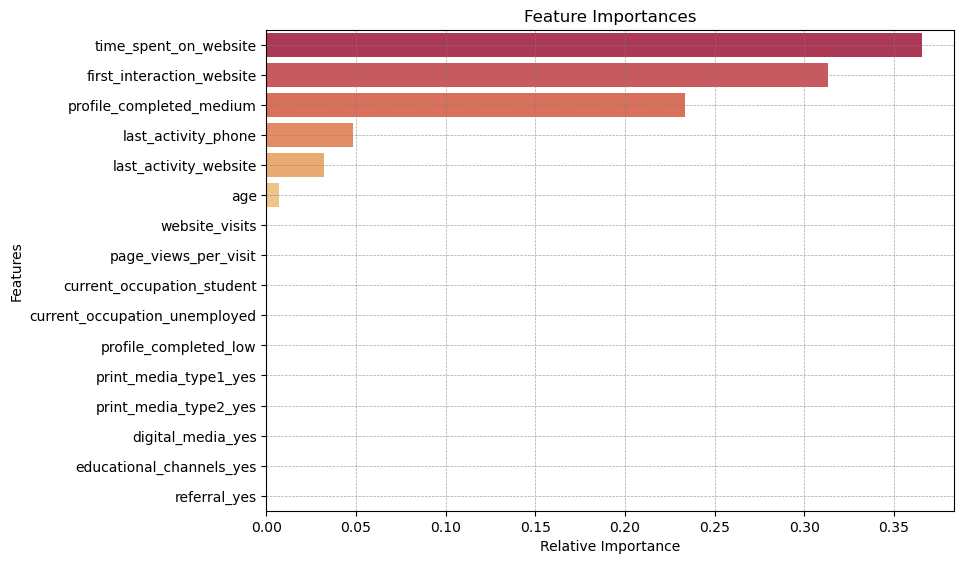

```python
# Plot the feature importance
plt.figure(figsize=(10, 6))
plt.title("Feature Importances")
sns.barplot(
    data=importance_df,
    x="relative_importance",
    y=importance_df.index,
    palette="Spectral",
)
plt.xlabel("Relative Importance")
plt.ylabel("Features")
plt.grid(True, color="grey", linestyle="--", linewidth=0.5, alpha=palette_alpha)

# Adjust layout and show the plot
plt.tight_layout(pad=2.0)
plt.show()
```

**Observations**:

- **Key Features**: The top contributors are time_spent_on_website, first_interaction_website, and profile_completed_medium, emphasizing the importance of sustained user engagement and detailed profile completion in driving lead conversion.
- **Supporting Features**: Moderate influence is observed from recent communication activities, with last_activity, particularly phone and website interactions, playing a notable role in predicting conversions.
- **Others**: The remaining features show minimal impact, suggesting limited relevance to the model’s predictive power. Features related to print and digital media have zero influence, underscoring their lack of role in predicting lead conversions.

## Model 3: Random Forest

### Building Random Forest Model

```python
# Building Random Forest model
model_rf = RandomForestClassifier(random_state=1)

# Fitting the model on the training data
model_rf.fit(X_train, y_train)
```

```
RandomForestClassifier(random_state=1)
```

### Evaluating Model Performance

```
Training Performance:
              precision    recall  f1-score   support

           0       1.00      1.00      1.00      2264
           1       1.00      1.00      1.00       964

    accuracy                           1.00      3228
   macro avg       1.00      1.00      1.00      3228
weighted avg       1.00      1.00      1.00      3228
```

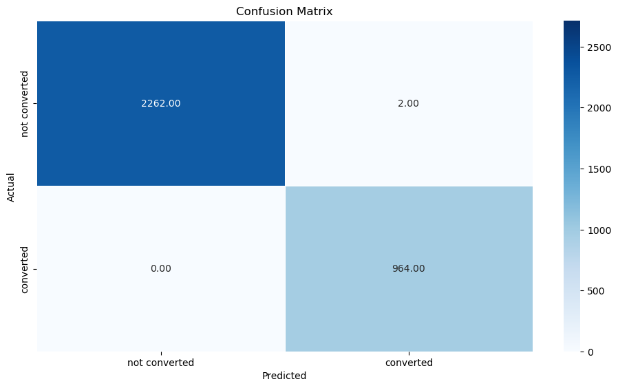

```
Testing Performance:
              precision    recall  f1-score   support

           0       0.89      0.91      0.90       971
           1       0.78      0.72      0.75       413

    accuracy                           0.86      1384
   macro avg       0.83      0.82      0.83      1384
weighted avg       0.86      0.86      0.86      1384
```

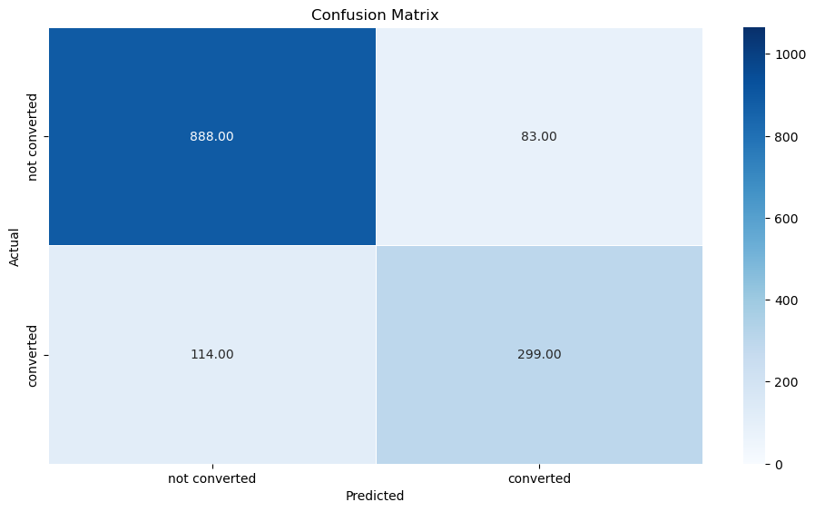

```python
# Predicting on the training and testing data
y_train_pred_rf = model_rf.predict(X_train)
y_test_pred_rf = model_rf.predict(X_test)

# Evaluating the model on the training data
print("Training Performance:")
model_rf_train_metrics = metrics_score(y_train, y_train_pred_rf)

# Evaluating the model on the testing data
print("Testing Performance:")
model_rf_test_metrics = metrics_score(y_test, y_test_pred_rf)
```

**Observations**:

- **Train Dataset**: The random forest achieves perfect metrics (accuracy, precision, and recall of 1.00), with only 2 false positives. This reflects overfitting, as the model memorizes training patterns rather than generalizing effectively.
- **Test Dataset**: Performance declines due to overfitting, with an accuracy of 0.86, precision of 0.78, and recall of 0.72 for the converted class. The confusion matrix reveals 114 false negatives and 83 false positives, underscoring challenges in identifying converted leads and generalizing to unseen data.
- **Hyperparameter Tuning**: Adjustments such as reducing max_depth, increasing min_samples_leaf, or tuning class_weight and n_estimators can mitigate overfitting, improving generalization and better balancing recall and precision to align with the business goal of maximizing lead identification.

### Hyperparameter Tuning

The target variable imbalance is addressed by setting the class_weight to {0: 0.3, 1: 0.7}, prioritizing converted leads (class 1) during model training. Hyperparameter tuning, performed via GridSearchCV, optimizes the random forest model by identifying the best parameter combinations:

- **n_estimators**: Number of trees in the random forest, influencing the ensemble size.
- **max_depth**: Maximum depth of each tree, controlling model complexity and mitigating overfitting.
- **min_samples_leaf**: Minimum samples required for a leaf node, preventing overfitting by ensuring splits have sufficient data.
- **max_features**: Maximum number of features considered for the best split in each tree.
- **max_samples**: Number of samples drawn from the training data for each tree, managing diversity within the ensemble.

```python
# Building the random forest model with initial parameters
model_rf_tuned = RandomForestClassifier(
    random_state=1, criterion="entropy", class_weight={0: 0.3, 1: 0.70}
)
```

```python
# Define the grid of parameters to search
param_grid_rf = {
    "n_estimators": [100, 150],
    "max_depth": [3, 5, 7],
    "min_samples_leaf": [5, 10, 20, 25],
    "max_features": ["sqrt", "log2"],
    "max_samples": [0.8, 0.9, 1],
}

# Initialize and run the grid search with cross-validation
gs_rf = GridSearchCV(model_rf_tuned, param_grid_rf, scoring="recall", cv=6, n_jobs=-1)
gs_rf = gs_rf.fit(X_train, y_train)

# Get the best parameters and best score
best_params_rf = gs_rf.best_params_
best_score_rf = gs_rf.best_score_

print(f"Best Parameters: {best_params_rf}")
print(f"Best Recall Score: {best_score_rf:.4f}")
```

```
Best Parameters: {'max_depth': 3, 'max_features': 'sqrt', 'max_samples': 0.9, 'min_samples_leaf': 10, 'n_estimators': 100}
Best Recall Score: 0.8775
```

```python
# Update the classifier with the best found parameters
model_rf_tuned = gs_rf.best_estimator_

# Fit the tuned model on the training data
model_rf_tuned.fit(X_train, y_train)
```

```
RandomForestClassifier(class_weight={0: 0.3, 1: 0.7}, criterion='entropy',
                       max_depth=3, max_samples=0.9, min_samples_leaf=10,
                       random_state=1)
```

### Evaluating Model Performance

```
Training Performance with Best Estimator:
              precision    recall  f1-score   support

           0       0.95      0.80      0.87      2264
           1       0.66      0.89      0.76       964

    accuracy                           0.83      3228
   macro avg       0.80      0.85      0.81      3228
weighted avg       0.86      0.83      0.83      3228
```

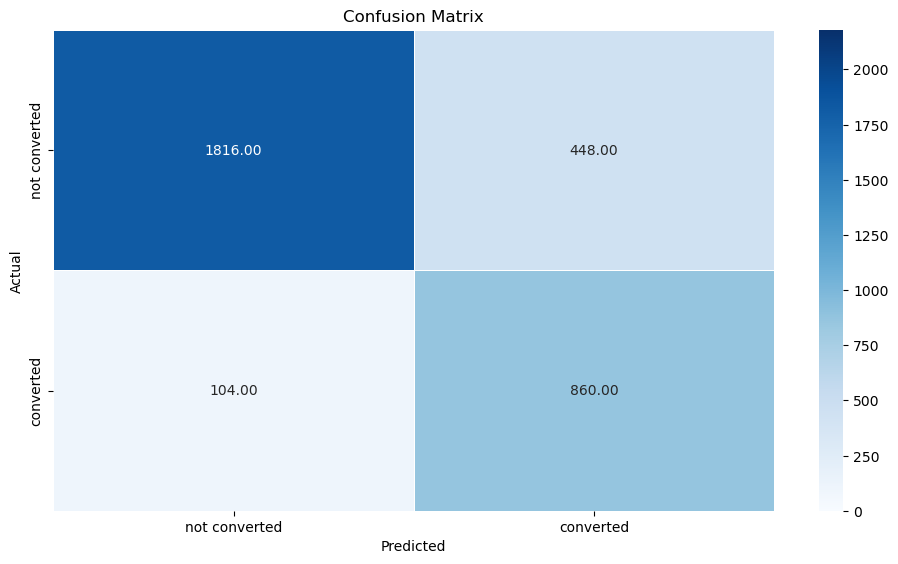

```
Testing Performance with Best Estimator:
              precision    recall  f1-score   support

           0       0.94      0.81      0.87       971
           1       0.66      0.88      0.76       413

    accuracy                           0.83      1384
   macro avg       0.80      0.85      0.81      1384
weighted avg       0.86      0.83      0.84      1384
```

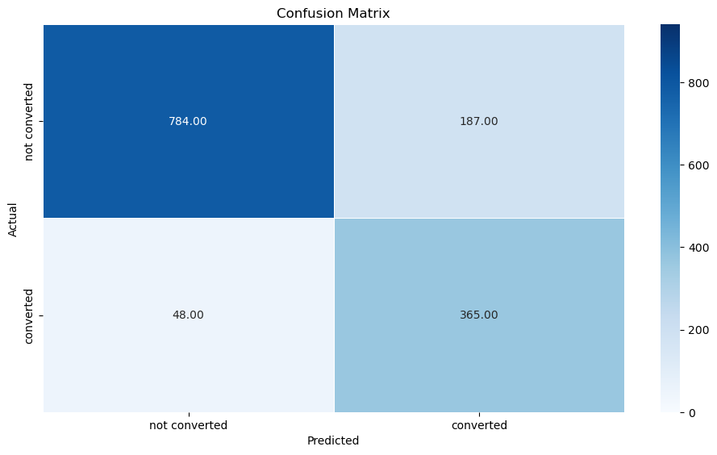

```python
# Predict on the training and testing data using the best estimator
y_train_pred_rf_tuned = model_rf_tuned.predict(X_train)
y_test_pred_rf_tuned = model_rf_tuned.predict(X_test)

# Evaluate the model on the training data
print("Training Performance with Best Estimator:")
model_rf_tuned_train_metrics = metrics_score(y_train, y_train_pred_rf_tuned)

# Evaluate the model on the testing data
print("Testing Performance with Best Estimator:")
model_rf_tuned_test_metrics = metrics_score(y_test, y_test_pred_rf_tuned)
```

**Observations**:

- **Improved Generalization**: Hyperparameter tuning reduces overfitting and balances performance across training and test datasets, enhancing the model’s practical applicability.
- **Train Dataset**: Accuracy decreases from 1.00 to 0.83, reflecting improved generalization. Recall drops slightly from 1.00 to 0.89, increasing false negatives from 0 to 104, while precision decreases from 1.00 to 0.66, leading to an increase in false positives from 2 to 448. This trade-off reduces overfitting and improves the model’s robustness.
- **Test Dataset**: Accuracy decreases slightly from 0.86 to 0.83, reflecting the trade-off between precision and recall. Recall improves significantly from 0.72 to 0.88, reducing false negatives from 114 to 48, while precision decreases from 0.78 to 0.66, increasing false positives from 83 to 187. This balance enhances the model’s ability to prioritize true positives while managing resource efficiency.
- **Business Relevance**: The tuned model prioritizes recall, reducing missed opportunities and aligning with the business objective of maximizing lead identification. Although increased false positives introduce inefficiencies, the significant reduction in false negatives ensures effective lead prioritization and resource allocation.

### Feature Importance

The main drawback of ensemble methods is the loss of interpretability in model decision rules. However, feature importance can still be extracted and analyzed, reflecting the aggregated contribution of features across multiple trees in the random forest and providing a robust assessment of feature relevance.

```python
# Get the feature names from the original DataFrame
features = X_train.columns

# Extract the feature importances
importances = model_rf_tuned.feature_importances_


importance_df = pd.DataFrame(
    importances, index=features, columns=["relative_importance"]
).sort_values(by="relative_importance", ascending=False)

print("Feature Importances | Random Forest")
print("-" * 52)
print(importance_df)
print("-" * 52)
```

```
Feature Importances | Random Forest
----------------------------------------------------
                               relative_importance
first_interaction_website                 0.337556
time_spent_on_website                     0.331350
profile_completed_medium                  0.117904
age                                       0.061615
last_activity_phone                       0.043806
current_occupation_student                0.038761
last_activity_website                     0.023167
page_views_per_visit                      0.010395
referral_yes                              0.010382
profile_completed_low                     0.009663
current_occupation_unemployed             0.007529
website_visits                            0.005619
print_media_type1_yes                     0.001070
print_media_type2_yes                     0.000664
digital_media_yes                         0.000287
educational_channels_yes                  0.000234
----------------------------------------------------
```

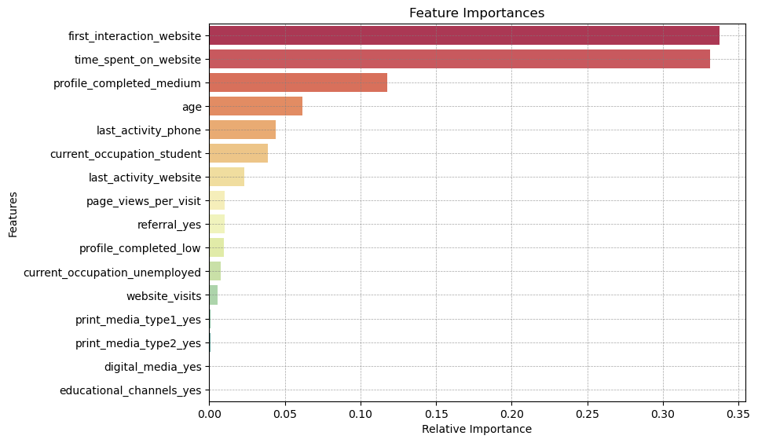

```python
# Plot the feature importance
plt.figure(figsize=(10, 6))
plt.title("Feature Importances")
sns.barplot(
    data=importance_df,
    x="relative_importance",
    y=importance_df.index,
    palette="Spectral",
)
plt.xlabel("Relative Importance")
plt.ylabel("Features")
plt.grid(True, color="grey", linestyle="--", linewidth=0.5, alpha=palette_alpha)

# Adjust layout and show the plot
plt.tight_layout(pad=2.0)
plt.show()
```

**Observations**:

- **Key Features**: The top contributors are first_interaction_website, time_spent_on_website, and profile_completed_medium, emphasizing the importance of user engagement and profile completion in predicting lead conversion.
- **Supporting Features**: Moderate influence comes from age, last_activity (particularly phone interactions), and current_occupation_student, underscoring the role of demographics and recent communication in determining conversion likelihood.
- **Others:** The remaining features show minimal impact, suggesting limited relevance to the model’s predictive power.

## Model Comparison

```python
def display_metrics(metrics, title):
    """
    Display the metrics in a formatted DataFrame.

    Args:
        metrics (dict): Dictionary containing the metrics.
        title (str): Title for the metrics display.
    """
    # Convert the metrics dictionary into a DataFrame
    metrics_df = pd.DataFrame(metrics).T

    # Capitalize the column names
    metrics_df.columns = metrics_df.columns.str.capitalize()

    # Display the DataFrame
    display(Markdown(f"**{title}**"))
    display(metrics_df)
```

```python
# Define metric dictionaries
baseline_metrics = {
    "Logistic Regression": model_lr_test_metrics,
    "Decision Tree": model_dt_test_metrics,
    "Random Forest": model_rf_test_metrics,
}

tuned_metrics = {
    "Logistic Regression": model_lr_tuned_test_metrics,
    "Decision Tree": model_dt_tuned_test_metrics,
    "Random Forest": model_rf_tuned_test_metrics,
}

# Display baseline metrics
display_metrics(baseline_metrics, "Baseline Model Metrics")

# Display tuned metrics
display_metrics(tuned_metrics, "Tuned Model Metrics")
```

**Baseline Model Metrics**

|  | Accuracy | Precision | Recall | F1_score |
| --- | --- | --- | --- | --- |
| Logistic Regression | 0.828 | 0.752 | 0.632 | 0.687 |
| Decision Tree | 0.800 | 0.670 | 0.649 | 0.659 |
| Random Forest | 0.858 | 0.783 | 0.724 | 0.752 |

**Tuned Model Metrics**

|  | Accuracy | Precision | Recall | F1_score |
| --- | --- | --- | --- | --- |
| Logistic Regression | 0.798 | 0.618 | 0.852 | 0.716 |
| Decision Tree | 0.777 | 0.583 | 0.889 | 0.704 |
| Random Forest | 0.830 | 0.661 | 0.884 | 0.756 |

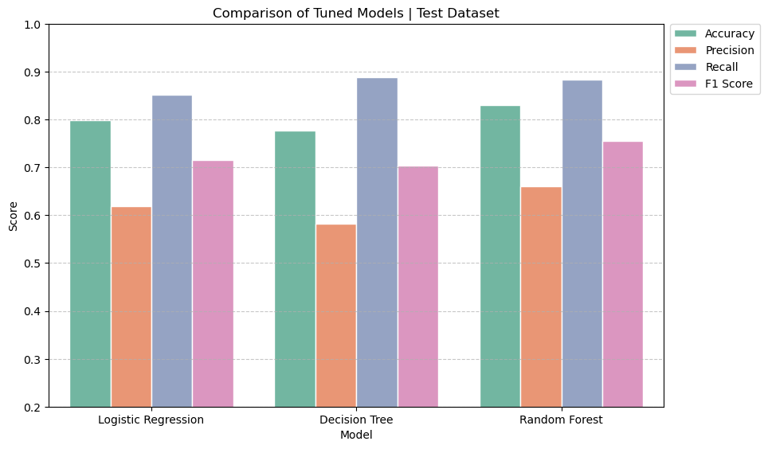

```python
# Convert the dictionary to a DataFrame
tuned_metrics_df = pd.DataFrame(tuned_metrics).T

# Melt the DataFrame to along format for visualization
tuned_metrics_df.reset_index(inplace=True)
metrics_long = pd.melt(
    tuned_metrics_df, id_vars="index", var_name="Metric", value_name="Score"
)

# Rename columns for clarity
metrics_long.columns = ["Model", "Metric", "Score"]

# Plot the metrics for the tuned models
plt.figure(figsize=(10, 6))
sns.barplot(
    x="Model",
    y="Score",
    hue="Metric",
    palette=palette_color,
    data=metrics_long,
    edgecolor="white",
)

# Format legend entries
handles, labels = plt.gca().get_legend_handles_labels()
labels = [label.replace("_", " ").title() for label in labels]
plt.legend(
    handles, labels, bbox_to_anchor=(1.01, 1), loc="upper left", borderaxespad=0.0
)

# Add a title and grid
plt.title("Comparison of Tuned Models | Test Dataset")
plt.grid(axis="y", linestyle="--", alpha=0.7)
plt.ylim(0.2, 1)

# Adjust layout and show the plot
plt.tight_layout(pad=2.0)
plt.show()
```

**Observations**:

All models demonstrated strong performance in recall, effectively capturing a high percentage of actual conversions. However, they differ significantly in precision and overall balance, with some models offering more well-rounded metrics that better align with the business objective of optimizing lead identification and resource allocation.

- **Logistic Regression**: This model demonstrates strong recall (0.852), capturing 85.2% of actual conversions, making it effective for identifying high-potential leads. However, its lower precision (0.618) results in 38.2% of predicted conversions being incorrect, introducing some resource inefficiencies.
- **Decision Tree**: With the highest recall (0.889), this model minimizes missed opportunities by identifying 88.9% of actual conversions. However, its precision (0.583) is the lowest among the models, indicating a higher rate of false positives, which could necessitate additional resource allocation to manage inefficiencies.
- **Random Forest**: Delivering the highest accuracy (0.830) and precision (0.661), this model achieves a well-rounded performance. Its recall (0.884) is strong and only marginally lower than the decision tree’s recall, highlighting minimal difference in their ability to capture actual conversions. This balance makes the random forest effective for optimizing lead identification while managing resource efficiency, aligning well with the business objective.

### Export of Tuned Model

```python
# Initialize the best model with tuned parameters
best_model = {
    "model": model_rf_tuned,
    "params": best_params_rf,
}

# Retrain the model on the full dataset
best_model["model"].fit(X, Y)

# Define the export path and filename
filename = "../models/random_forest_final.pkl"

# Export the final trained model
with open(filename, "wb") as f:
    pickle.dump(best_model["model"], f)

# Print status log
print(f"Parameters: {best_model['params']}")
print(f"Tuned model exported successfully to '{filename}'")
```

```
Parameters: {'max_depth': 3, 'max_features': 'sqrt', 'max_samples': 0.9, 'min_samples_leaf': 10, 'n_estimators': 100}
Tuned model exported successfully to '../models/random_forest_final.pkl'
```

## Conclusion and Recommendations

### Conclusion

This analysis utilized machine learning models to uncover key drivers of lead conversion and evaluate model performance, while exploratory data analysis provided deeper insights into the demographic, behavioral, and referral-based traits influencing conversions. Together, these findings align with the business objective of prioritizing high-potential leads and optimizing resource allocation to drive growth.

**Machine Learning Insights for Business Growth**

Models identified key drivers of conversions and assessed their ability to support business growth objectives.

1. **Key Drivers of Conversion**
   - Across all models, time_spent_on_website and first_interaction_website emerged as critical predictors, emphasizing the importance of sustained engagement and effective initial interactions.
   - Tree-based models identified additional factors, including profile_completed_medium, last_activity, and age, emphasizing the roles of detailed profile completion, recent communication, and older demographics in driving conversions.
   - Referrals, while achieving a 67.7% conversion rate, have limited model impact due to their minimal representation in the dataset.
2. **Model Performance**
   - The **random forest** model demonstrated the best overall balance, with a recall of 0.884 and the highest precision (0.661), making it the most effective choice for lead prioritization. Its lower false positive rate further aligns with the business objective of optimizing resource allocation while maximizing conversions.
   - For stakeholders prioritizing performance alone, the decision tree offers slightly higher recall (0.889) and interpretable decision paths. However, its higher false positive rate makes it less efficient for resource optimization compared to the random forest.

**Conversion Profiles for Targeted Engagement**

Data-driven insights offered a deeper understanding of lead characteristics to enhance targeted strategies and inform strategic decision-making in a competitive market.

1. **Demographic Insights**
   - **Occupation**: Professionals (35.5%) and unemployed individuals (26.6%) lead conversion rates, while students lag at 11.7%, indicating the need for tailored engagement strategies, particularly for the student demographic.
   - **Age**: Converted leads are typically older, with a median age of 54 compared to 49 for non-converted leads, highlighting the potential of targeting older demographics. The overall age range is 18 to 63 years, with a median of 51.
2. **Behavioral Engagement**
   - **Time Spent**: Converted leads spend significantly more time on the website (median: ~13 minutes) compared to non-converted leads (median: ~5 minutes), reinforcing the correlation between extended browsing and conversion likelihood.
   - **Profile Completion**: Conversion rates increase with profile completion, from 7.5% (low completion) to 18.9% (medium) and 41.8% (high). Encouraging detailed profile completion presents a clear opportunity to boost conversion rates.
   - **First Interaction**: Leads interacting through the website convert at 45.6%, far outperforming mobile app interactions (10.5%), underlining the website’s superior engagement potential.
   - **Last Activity**: Website-related activities deliver the highest conversion rate (38.5%), followed by email activities (30.3%). Phone interactions trail at 21.3%, emphasizing the importance of prioritizing website engagement.
3. **Referral Effectiveness**
   - **High Conversion Potential**: Referrals demonstrate an exceptional conversion rate of 67.7%, underscoring their ability to generate high-quality leads. However, their limited representation highlights the opportunity to expand referral programs as a strategic initiative to drive conversions further.

### Business Recommendations

This set of recommendations focuses on improving lead prioritization, refining user interactions, and leveraging data-driven insights to maximize conversions and business outcomes.

1. **Enhance Website Engagement**
   - Improve user experience to encourage longer visits and more page views.
   - Simplify navigation and ensure the website is mobile-responsive and fast-loading for seamless engagement.
   - Introduce interactive features like live chat and personalized recommendations to boost engagement.
   - Track pages per session and bounce rate to measure user engagement and identify areas for improvement.
2. **Promote Profile Completion**
   - Implement gamification, progress indicators, or incentives to motivate users to complete their profiles.
   - Simplify the completion process by reducing required fields and providing clear guidance on its value.
   - Highlight the benefits of a completed profile to improve participation rates.
   - Measure success using lead form submissions to track profile completion progress.
3. **Optimize Interaction Channels**
   - Prioritize website and email interactions due to their higher conversion rates (38.5% and 30.3%).
   - Enhance mobile app functionality and engagement strategies to increase its effectiveness.
   - Focus phone-based outreach on personalized follow-ups for high-value leads.
   - Monitor the qualified lead rate (MQLs) to evaluate channel effectiveness.
4. **Targeted Marketing**
   - Customize campaigns for professionals and unemployed individuals using platforms like LinkedIn and professional networks.
   - Address lower student conversion rates by offering discounts, flexible payment plans, or course bundles integrated with institutional curricula.
   - Use demographic insights to craft messaging that resonates with specific segments.
   - Prioritize channels with proven conversion potential, as print media and educational platforms showed minimal impact in both EDA and predictive modeling.
   - Measure the impact of campaigns by analyzing traffic from targeted user segments using the unique visitors metric.
5. **Leverage Referral Programs**
   - Expand referral programs to capitalize on their high conversion effectiveness (67.7%) despite their limited contribution to overall conversions.
   - Promote referrals through social media integration, personalized email campaigns, and attractive incentives.
   - Enable seamless sharing of referral links via popular social platforms.
   - Track referral success by monitoring lead form submissions attributed to referrals.
6. **Continuous Model Improvement**
   - Regularly update and fine-tune predictive models to maintain high accuracy and adapt to changing user behaviors.
   - Use feature importance insights to refine lead nurturing strategies.
   - Align model outputs with marketing and sales goals to optimize resource allocation and maximize conversions.
   - Monitor cost per lead (CPL) to ensure alignment with ROI objectives.